# Risk Factor Analysis

## Outcome Variable

**Outcome Variable:** ever_wasted

## Predictor Variables

**Intervention Variable:** fage

**Adjustment Set:**

- arm
- W_mage
- meducyrs
- feducyrs
- W_mhtcm
- W_mwtkg
- W_mbmi
- W_fhtcm
- single
- brthmon
- delta_W_mage
- delta_meducyrs
- delta_feducyrs
- delta_W_mhtcm
- delta_W_mwtkg
- delta_W_mbmi
- delta_W_fhtcm
- delta_single
- delta_brthmon

## Stratifying Variables

The analysis was stratified on these variable(s):

- agecat
- studyid
- country

## Data Summary

| agecat | studyid | country | fage | ever_wasted | n_cell | n |
| --- | --- | --- | --- | --- | --- | --- |
| 0-24 months | ki0047075b-MAL-ED | BANGLADESH | >=38 | 0 | 46 | 151 |
| 0-24 months | ki0047075b-MAL-ED | BANGLADESH | >=38 | 1 | 23 | 151 |
| 0-24 months | ki0047075b-MAL-ED | BANGLADESH | <32 | 0 | 15 | 151 |
| 0-24 months | ki0047075b-MAL-ED | BANGLADESH | <32 | 1 | 15 | 151 |
| 0-24 months | ki0047075b-MAL-ED | BANGLADESH | [32-38) | 0 | 39 | 151 |
| 0-24 months | ki0047075b-MAL-ED | BANGLADESH | [32-38) | 1 | 13 | 151 |
| 0-24 months | ki0047075b-MAL-ED | BRAZIL | >=38 | 0 | 30 | 79 |
| 0-24 months | ki0047075b-MAL-ED | BRAZIL | >=38 | 1 | 0 | 79 |
| 0-24 months | ki0047075b-MAL-ED | BRAZIL | <32 | 0 | 16 | 79 |
| 0-24 months | ki0047075b-MAL-ED | BRAZIL | <32 | 1 | 2 | 79 |
| 0-24 months | ki0047075b-MAL-ED | BRAZIL | [32-38) | 0 | 28 | 79 |
| 0-24 months | ki0047075b-MAL-ED | BRAZIL | [32-38) | 1 | 3 | 79 |
| 0-24 months | ki0047075b-MAL-ED | INDIA | >=38 | 0 | 25 | 161 |
| 0-24 months | ki0047075b-MAL-ED | INDIA | >=38 | 1 | 11 | 161 |
| 0-24 months | ki0047075b-MAL-ED | INDIA | <32 | 0 | 20 | 161 |
| 0-24 months | ki0047075b-MAL-ED | INDIA | <32 | 1 | 33 | 161 |
| 0-24 months | ki0047075b-MAL-ED | INDIA | [32-38) | 0 | 36 | 161 |
| 0-24 months | ki0047075b-MAL-ED | INDIA | [32-38) | 1 | 36 | 161 |
| 0-24 months | ki0047075b-MAL-ED | NEPAL | >=38 | 0 | 13 | 79 |
| 0-24 months | ki0047075b-MAL-ED | NEPAL | >=38 | 1 | 4 | 79 |
| 0-24 months | ki0047075b-MAL-ED | NEPAL | <32 | 0 | 8 | 79 |
| 0-24 months | ki0047075b-MAL-ED | NEPAL | <32 | 1 | 7 | 79 |
| 0-24 months | ki0047075b-MAL-ED | NEPAL | [32-38) | 0 | 34 | 79 |
| 0-24 months | ki0047075b-MAL-ED | NEPAL | [32-38) | 1 | 13 | 79 |
| 0-24 months | ki0047075b-MAL-ED | PERU | >=38 | 0 | 26 | 85 |
| 0-24 months | ki0047075b-MAL-ED | PERU | >=38 | 1 | 1 | 85 |
| 0-24 months | ki0047075b-MAL-ED | PERU | <32 | 0 | 25 | 85 |
| 0-24 months | ki0047075b-MAL-ED | PERU | <32 | 1 | 4 | 85 |
| 0-24 months | ki0047075b-MAL-ED | PERU | [32-38) | 0 | 26 | 85 |
| 0-24 months | ki0047075b-MAL-ED | PERU | [32-38) | 1 | 3 | 85 |

[output cut: 204 more lines]

The following strata were considered:

- agecat: 0-24 months, studyid: ki0047075b-MAL-ED, country: BANGLADESH
- agecat: 0-24 months, studyid: ki0047075b-MAL-ED, country: BRAZIL
- agecat: 0-24 months, studyid: ki0047075b-MAL-ED, country: INDIA
- agecat: 0-24 months, studyid: ki0047075b-MAL-ED, country: NEPAL
- agecat: 0-24 months, studyid: ki0047075b-MAL-ED, country: PERU
- agecat: 0-24 months, studyid: ki0047075b-MAL-ED, country: SOUTH AFRICA
- agecat: 0-24 months, studyid: ki0047075b-MAL-ED, country: TANZANIA, UNITED REPUBLIC OF
- agecat: 0-24 months, studyid: ki1000304b-SAS-CompFeed, country: INDIA
- agecat: 0-24 months, studyid: ki1000304b-SAS-FoodSuppl, country: INDIA
- agecat: 0-24 months, studyid: ki1119695-PROBIT, country: BELARUS
- agecat: 0-24 months, studyid: ki1135781-COHORTS, country: GUATEMALA
- agecat: 0-24 months, studyid: ki1135781-COHORTS, country: PHILIPPINES
- agecat: 0-24 months, studyid: ki1148112-LCNI-5, country: MALAWI
- agecat: 0-6 months, studyid: ki0047075b-MAL-ED, country: BANGLADESH
- agecat: 0-6 months, studyid: ki0047075b-MAL-ED, country: BRAZIL
- agecat: 0-6 months, studyid: ki0047075b-MAL-ED, country: INDIA
- agecat: 0-6 months, studyid: ki0047075b-MAL-ED, country: NEPAL
- agecat: 0-6 months, studyid: ki0047075b-MAL-ED, country: PERU
- agecat: 0-6 months, studyid: ki0047075b-MAL-ED, country: SOUTH AFRICA
- agecat: 0-6 months, studyid: ki0047075b-MAL-ED, country: TANZANIA, UNITED REPUBLIC OF
- agecat: 0-6 months, studyid: ki1000304b-SAS-CompFeed, country: INDIA
- agecat: 0-6 months, studyid: ki1000304b-SAS-FoodSuppl, country: INDIA
- agecat: 0-6 months, studyid: ki1119695-PROBIT, country: BELARUS
- agecat: 0-6 months, studyid: ki1135781-COHORTS, country: GUATEMALA
- agecat: 0-6 months, studyid: ki1135781-COHORTS, country: PHILIPPINES
- agecat: 0-6 months, studyid: ki1148112-LCNI-5, country: MALAWI
- agecat: 6-24 months, studyid: ki0047075b-MAL-ED, country: BANGLADESH
- agecat: 6-24 months, studyid: ki0047075b-MAL-ED, country: BRAZIL
- agecat: 6-24 months, studyid: ki0047075b-MAL-ED, country: INDIA
- agecat: 6-24 months, studyid: ki0047075b-MAL-ED, country: NEPAL
- agecat: 6-24 months, studyid: ki0047075b-MAL-ED, country: PERU
- agecat: 6-24 months, studyid: ki0047075b-MAL-ED, country: SOUTH AFRICA
- agecat: 6-24 months, studyid: ki0047075b-MAL-ED, country: TANZANIA, UNITED REPUBLIC OF
- agecat: 6-24 months, studyid: ki1000304b-SAS-CompFeed, country: INDIA
- agecat: 6-24 months, studyid: ki1000304b-SAS-FoodSuppl, country: INDIA
- agecat: 6-24 months, studyid: ki1119695-PROBIT, country: BELARUS
- agecat: 6-24 months, studyid: ki1135781-COHORTS, country: GUATEMALA
- agecat: 6-24 months, studyid: ki1135781-COHORTS, country: PHILIPPINES
- agecat: 6-24 months, studyid: ki1148112-LCNI-5, country: MALAWI

### Dropped Strata

Some strata were dropped due to rare outcomes:

- agecat: 0-24 months, studyid: ki0047075b-MAL-ED, country: BRAZIL
- agecat: 0-24 months, studyid: ki0047075b-MAL-ED, country: NEPAL
- agecat: 0-24 months, studyid: ki0047075b-MAL-ED, country: PERU
- agecat: 0-24 months, studyid: ki0047075b-MAL-ED, country: SOUTH AFRICA
- agecat: 0-24 months, studyid: ki0047075b-MAL-ED, country: TANZANIA, UNITED REPUBLIC OF
- agecat: 0-24 months, studyid: ki1148112-LCNI-5, country: MALAWI
- agecat: 0-6 months, studyid: ki0047075b-MAL-ED, country: BRAZIL
- agecat: 0-6 months, studyid: ki0047075b-MAL-ED, country: NEPAL
- agecat: 0-6 months, studyid: ki0047075b-MAL-ED, country: PERU
- agecat: 0-6 months, studyid: ki0047075b-MAL-ED, country: SOUTH AFRICA
- agecat: 0-6 months, studyid: ki0047075b-MAL-ED, country: TANZANIA, UNITED REPUBLIC OF
- agecat: 0-6 months, studyid: ki1148112-LCNI-5, country: MALAWI
- agecat: 6-24 months, studyid: ki0047075b-MAL-ED, country: BRAZIL
- agecat: 6-24 months, studyid: ki0047075b-MAL-ED, country: NEPAL
- agecat: 6-24 months, studyid: ki0047075b-MAL-ED, country: PERU
- agecat: 6-24 months, studyid: ki0047075b-MAL-ED, country: SOUTH AFRICA
- agecat: 6-24 months, studyid: ki0047075b-MAL-ED, country: TANZANIA, UNITED REPUBLIC OF
- agecat: 6-24 months, studyid: ki1148112-LCNI-5, country: MALAWI

## Methods Detail

We’re interested in the causal parameters $E[Y_a]$ for all values of $a \in \mathcal{A}$. These parameters represent the mean outcome if, possibly contrary to fact, we intervened to set all units to have $A=a$. Under the randomization and positivity assumptions, these are identified by the statistical parameters $\psi_a=E_W[E_{Y|A,W}(Y|A=a,W)]$. In addition, we’re interested in the mean of $Y$, $E[Y]$ under no intervention (the observed mean). We will estimate these parameters by using SuperLearner to fit the relevant likelihood factors – $E_{Y|A,W}(Y|A=a,W)$ and $p(A=a|W)$, and then updating our likelihood fit using a joint TMLE.

For unadjusted analyses ($W=\{\}$), initial likelihoods were estimated using Lrnr_glm to estimate the simple $E(Y|A)$ and Lrnr_mean to estimate $p(A)$. For adjusted analyses, a small library containing Lrnr_glmnet, Lrnr_xgboost, and Lrnr_mean was used.

Having estimated these parameters, we will then use the delta method to estimate relative risks and attributable risks relative to a prespecified baseline level of $A$.

# Results Detail

## Results Plots

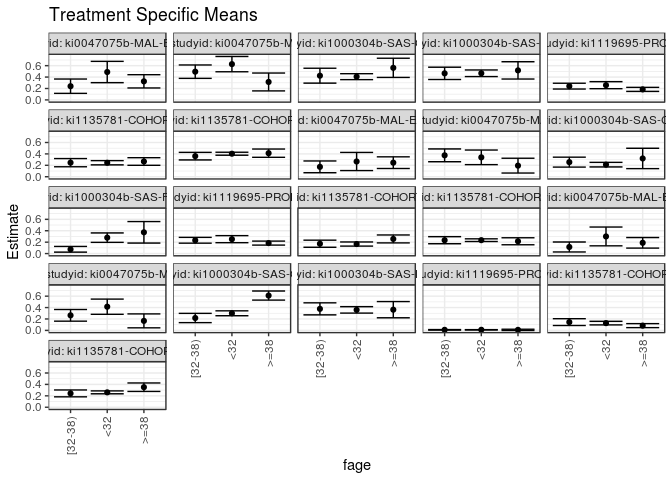

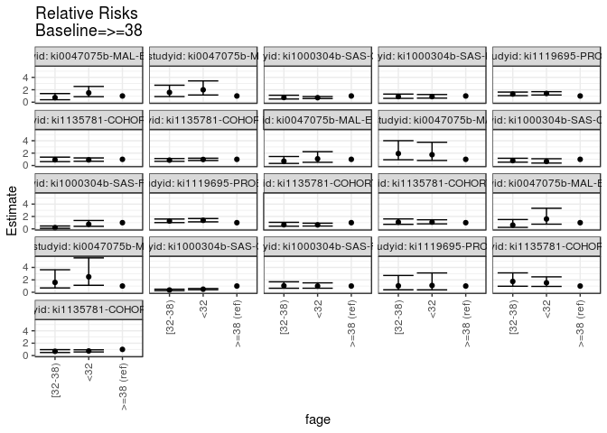

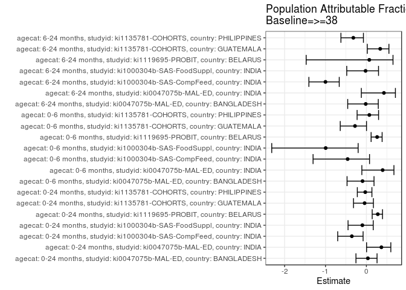

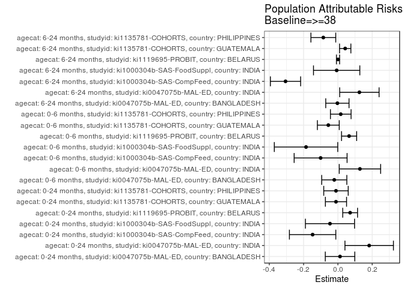

## Results Table

### Parameter: TSM

| agecat | studyid | country | intervention_level | baseline_level | estimate | ci_lower | ci_upper |
| --- | --- | --- | --- | --- | --- | --- | --- |
| 0-24 months | ki0047075b-MAL-ED | BANGLADESH | >=38 | NA | 0.3252639 | 0.2090292 | 0.4414986 |
| 0-24 months | ki0047075b-MAL-ED | BANGLADESH | <32 | NA | 0.4885569 | 0.3020423 | 0.6750714 |
| 0-24 months | ki0047075b-MAL-ED | BANGLADESH | [32-38) | NA | 0.2398166 | 0.1143378 | 0.3652953 |
| 0-24 months | ki0047075b-MAL-ED | INDIA | >=38 | NA | 0.3143961 | 0.1576872 | 0.4711050 |
| 0-24 months | ki0047075b-MAL-ED | INDIA | <32 | NA | 0.6269691 | 0.4929125 | 0.7610256 |
| 0-24 months | ki0047075b-MAL-ED | INDIA | [32-38) | NA | 0.4948108 | 0.3774029 | 0.6122187 |
| 0-24 months | ki1000304b-SAS-CompFeed | INDIA | >=38 | NA | 0.5619996 | 0.3937456 | 0.7302536 |
| 0-24 months | ki1000304b-SAS-CompFeed | INDIA | <32 | NA | 0.4072548 | 0.3554343 | 0.4590754 |
| 0-24 months | ki1000304b-SAS-CompFeed | INDIA | [32-38) | NA | 0.4244577 | 0.2937446 | 0.5551709 |
| 0-24 months | ki1000304b-SAS-FoodSuppl | INDIA | >=38 | NA | 0.5174492 | 0.3660445 | 0.6688539 |
| 0-24 months | ki1000304b-SAS-FoodSuppl | INDIA | <32 | NA | 0.4667708 | 0.4091498 | 0.5243918 |
| 0-24 months | ki1000304b-SAS-FoodSuppl | INDIA | [32-38) | NA | 0.4654400 | 0.3576457 | 0.5732342 |
| 0-24 months | ki1119695-PROBIT | BELARUS | >=38 | NA | 0.1841028 | 0.1488608 | 0.2193447 |
| 0-24 months | ki1119695-PROBIT | BELARUS | <32 | NA | 0.2581170 | 0.1965691 | 0.3196649 |
| 0-24 months | ki1119695-PROBIT | BELARUS | [32-38) | NA | 0.2412994 | 0.1901538 | 0.2924451 |
| 0-24 months | ki1135781-COHORTS | GUATEMALA | >=38 | NA | 0.2672304 | 0.2006327 | 0.3338281 |
| 0-24 months | ki1135781-COHORTS | GUATEMALA | <32 | NA | 0.2450225 | 0.2077161 | 0.2823289 |
| 0-24 months | ki1135781-COHORTS | GUATEMALA | [32-38) | NA | 0.2465675 | 0.1746555 | 0.3184794 |
| 0-24 months | ki1135781-COHORTS | PHILIPPINES | >=38 | NA | 0.4129830 | 0.3401800 | 0.4857859 |
| 0-24 months | ki1135781-COHORTS | PHILIPPINES | <32 | NA | 0.4033231 | 0.3772285 | 0.4294177 |
| 0-24 months | ki1135781-COHORTS | PHILIPPINES | [32-38) | NA | 0.3605047 | 0.2942238 | 0.4267856 |
| 0-6 months | ki0047075b-MAL-ED | BANGLADESH | >=38 | NA | 0.2463768 | 0.1443667 | 0.3483870 |
| 0-6 months | ki0047075b-MAL-ED | BANGLADESH | <32 | NA | 0.2666667 | 0.1078978 | 0.4254355 |
| 0-6 months | ki0047075b-MAL-ED | BANGLADESH | [32-38) | NA | 0.1730769 | 0.0699098 | 0.2762441 |
| 0-6 months | ki0047075b-MAL-ED | INDIA | >=38 | NA | 0.1944444 | 0.0647578 | 0.3241311 |
| 0-6 months | ki0047075b-MAL-ED | INDIA | <32 | NA | 0.3396226 | 0.2117265 | 0.4675188 |
| 0-6 months | ki0047075b-MAL-ED | INDIA | [32-38) | NA | 0.3750000 | 0.2628265 | 0.4871735 |
| 0-6 months | ki1000304b-SAS-CompFeed | INDIA | >=38 | NA | 0.3203655 | 0.1419059 | 0.4988251 |
| 0-6 months | ki1000304b-SAS-CompFeed | INDIA | <32 | NA | 0.2115571 | 0.1714884 | 0.2516257 |
| 0-6 months | ki1000304b-SAS-CompFeed | INDIA | [32-38) | NA | 0.2558912 | 0.1689365 | 0.3428459 |
| 0-6 months | ki1000304b-SAS-FoodSuppl | INDIA | >=38 | NA | 0.3723599 | 0.1839792 | 0.5607407 |
| 0-6 months | ki1000304b-SAS-FoodSuppl | INDIA | <32 | NA | 0.2789751 | 0.1964392 | 0.3615109 |
| 0-6 months | ki1000304b-SAS-FoodSuppl | INDIA | [32-38) | NA | 0.0747449 | 0.0248520 | 0.1246377 |
| 0-6 months | ki1119695-PROBIT | BELARUS | >=38 | NA | 0.1832749 | 0.1479861 | 0.2185638 |
| 0-6 months | ki1119695-PROBIT | BELARUS | <32 | NA | 0.2519810 | 0.1900871 | 0.3138750 |
| 0-6 months | ki1119695-PROBIT | BELARUS | [32-38) | NA | 0.2328545 | 0.1822772 | 0.2834318 |
| 0-6 months | ki1135781-COHORTS | GUATEMALA | >=38 | NA | 0.2564028 | 0.1866168 | 0.3261888 |
| 0-6 months | ki1135781-COHORTS | GUATEMALA | <32 | NA | 0.1665954 | 0.1304240 | 0.2027669 |
| 0-6 months | ki1135781-COHORTS | GUATEMALA | [32-38) | NA | 0.1723882 | 0.1104384 | 0.2343380 |
| 0-6 months | ki1135781-COHORTS | PHILIPPINES | >=38 | NA | 0.2154345 | 0.1542073 | 0.2766618 |
| 0-6 months | ki1135781-COHORTS | PHILIPPINES | <32 | NA | 0.2347090 | 0.2116330 | 0.2577850 |
| 0-6 months | ki1135781-COHORTS | PHILIPPINES | [32-38) | NA | 0.2341137 | 0.1722257 | 0.2960016 |
| 6-24 months | ki0047075b-MAL-ED | BANGLADESH | >=38 | NA | 0.1884058 | 0.0958331 | 0.2809785 |
| 6-24 months | ki0047075b-MAL-ED | BANGLADESH | <32 | NA | 0.3000000 | 0.1354719 | 0.4645281 |
| 6-24 months | ki0047075b-MAL-ED | BANGLADESH | [32-38) | NA | 0.1153846 | 0.0282601 | 0.2025091 |
| 6-24 months | ki0047075b-MAL-ED | INDIA | >=38 | NA | 0.1666667 | 0.0445476 | 0.2887858 |
| 6-24 months | ki0047075b-MAL-ED | INDIA | <32 | NA | 0.4150943 | 0.2820246 | 0.5481641 |
| 6-24 months | ki0047075b-MAL-ED | INDIA | [32-38) | NA | 0.2638889 | 0.1617674 | 0.3660104 |
| 6-24 months | ki1000304b-SAS-CompFeed | INDIA | >=38 | NA | 0.6106108 | 0.5309084 | 0.6903133 |
| 6-24 months | ki1000304b-SAS-CompFeed | INDIA | <32 | NA | 0.2996310 | 0.2567729 | 0.3424891 |
| 6-24 months | ki1000304b-SAS-CompFeed | INDIA | [32-38) | NA | 0.2170291 | 0.1357884 | 0.2982697 |
| 6-24 months | ki1000304b-SAS-FoodSuppl | INDIA | >=38 | NA | 0.3629155 | 0.2208898 | 0.5049411 |
| 6-24 months | ki1000304b-SAS-FoodSuppl | INDIA | <32 | NA | 0.3592451 | 0.3028610 | 0.4156292 |
| 6-24 months | ki1000304b-SAS-FoodSuppl | INDIA | [32-38) | NA | 0.3776052 | 0.2721260 | 0.4830845 |
| 6-24 months | ki1119695-PROBIT | BELARUS | >=38 | NA | 0.0095238 | -0.0012136 | 0.0202612 |
| 6-24 months | ki1119695-PROBIT | BELARUS | <32 | NA | 0.0103833 | 0.0077464 | 0.0130202 |
| 6-24 months | ki1119695-PROBIT | BELARUS | [32-38) | NA | 0.0098039 | 0.0053467 | 0.0142611 |
| 6-24 months | ki1135781-COHORTS | GUATEMALA | >=38 | NA | 0.0835563 | 0.0484395 | 0.1186730 |
| 6-24 months | ki1135781-COHORTS | GUATEMALA | <32 | NA | 0.1273615 | 0.0958598 | 0.1588632 |
| 6-24 months | ki1135781-COHORTS | GUATEMALA | [32-38) | NA | 0.1453227 | 0.0857624 | 0.2048831 |
| 6-24 months | ki1135781-COHORTS | PHILIPPINES | >=38 | NA | 0.3510831 | 0.2769620 | 0.4252043 |
| 6-24 months | ki1135781-COHORTS | PHILIPPINES | <32 | NA | 0.2606930 | 0.2351030 | 0.2862831 |
| 6-24 months | ki1135781-COHORTS | PHILIPPINES | [32-38) | NA | 0.2424198 | 0.1820003 | 0.3028392 |

### Parameter: E(Y)

| agecat | studyid | country | intervention_level | baseline_level | estimate | ci_lower | ci_upper |
| --- | --- | --- | --- | --- | --- | --- | --- |
| 0-24 months | ki0047075b-MAL-ED | BANGLADESH | NA | NA | 0.3377483 | 0.2620632 | 0.4134335 |
| 0-24 months | ki0047075b-MAL-ED | INDIA | NA | NA | 0.4968944 | 0.4194215 | 0.5743673 |
| 0-24 months | ki1000304b-SAS-CompFeed | INDIA | NA | NA | 0.4145695 | 0.3576236 | 0.4715155 |
| 0-24 months | ki1000304b-SAS-FoodSuppl | INDIA | NA | NA | 0.4712919 | 0.4233811 | 0.5192026 |
| 0-24 months | ki1119695-PROBIT | BELARUS | NA | NA | 0.2554368 | 0.1979772 | 0.3128964 |
| 0-24 months | ki1135781-COHORTS | GUATEMALA | NA | NA | 0.2560311 | 0.2321591 | 0.2799032 |
| 0-24 months | ki1135781-COHORTS | PHILIPPINES | NA | NA | 0.4018374 | 0.3841095 | 0.4195652 |
| 0-6 months | ki0047075b-MAL-ED | BANGLADESH | NA | NA | 0.2251656 | 0.1583223 | 0.2920089 |
| 0-6 months | ki0047075b-MAL-ED | INDIA | NA | NA | 0.3229814 | 0.2505249 | 0.3954378 |
| 0-6 months | ki1000304b-SAS-CompFeed | INDIA | NA | NA | 0.2197071 | 0.1750081 | 0.2644060 |
| 0-6 months | ki1000304b-SAS-FoodSuppl | INDIA | NA | NA | 0.1866029 | 0.1492099 | 0.2239959 |
| 0-6 months | ki1119695-PROBIT | BELARUS | NA | NA | 0.2485407 | 0.1903207 | 0.3067607 |
| 0-6 months | ki1135781-COHORTS | GUATEMALA | NA | NA | 0.2005842 | 0.1760818 | 0.2250867 |
| 0-6 months | ki1135781-COHORTS | PHILIPPINES | NA | NA | 0.2321307 | 0.2168619 | 0.2473995 |
| 6-24 months | ki0047075b-MAL-ED | BANGLADESH | NA | NA | 0.1854305 | 0.1232352 | 0.2476257 |
| 6-24 months | ki0047075b-MAL-ED | INDIA | NA | NA | 0.2919255 | 0.2214783 | 0.3623726 |
| 6-24 months | ki1000304b-SAS-CompFeed | INDIA | NA | NA | 0.3051948 | 0.2633957 | 0.3469939 |
| 6-24 months | ki1000304b-SAS-FoodSuppl | INDIA | NA | NA | 0.3557214 | 0.3088651 | 0.4025777 |
| 6-24 months | ki1119695-PROBIT | BELARUS | NA | NA | 0.0102551 | 0.0075905 | 0.0129198 |
| 6-24 months | ki1135781-COHORTS | GUATEMALA | NA | NA | 0.1261803 | 0.1071047 | 0.1452559 |
| 6-24 months | ki1135781-COHORTS | PHILIPPINES | NA | NA | 0.2661765 | 0.2495644 | 0.2827886 |

### Parameter: RR

| agecat | studyid | country | intervention_level | baseline_level | estimate | ci_lower | ci_upper |
| --- | --- | --- | --- | --- | --- | --- | --- |
| 0-24 months | ki0047075b-MAL-ED | BANGLADESH | >=38 | >=38 | 1.0000000 | 1.0000000 | 1.0000000 |
| 0-24 months | ki0047075b-MAL-ED | BANGLADESH | <32 | >=38 | 1.5020322 | 0.8890489 | 2.5376567 |
| 0-24 months | ki0047075b-MAL-ED | BANGLADESH | [32-38) | >=38 | 0.7372984 | 0.3914134 | 1.3888360 |
| 0-24 months | ki0047075b-MAL-ED | INDIA | >=38 | >=38 | 1.0000000 | 1.0000000 | 1.0000000 |
| 0-24 months | ki0047075b-MAL-ED | INDIA | <32 | >=38 | 1.9942013 | 1.1596553 | 3.4293283 |
| 0-24 months | ki0047075b-MAL-ED | INDIA | [32-38) | >=38 | 1.5738452 | 0.9055365 | 2.7353826 |
| 0-24 months | ki1000304b-SAS-CompFeed | INDIA | >=38 | >=38 | 1.0000000 | 1.0000000 | 1.0000000 |
| 0-24 months | ki1000304b-SAS-CompFeed | INDIA | <32 | >=38 | 0.7246533 | 0.5773474 | 0.9095430 |
| 0-24 months | ki1000304b-SAS-CompFeed | INDIA | [32-38) | >=38 | 0.7552635 | 0.5094567 | 1.1196691 |
| 0-24 months | ki1000304b-SAS-FoodSuppl | INDIA | >=38 | >=38 | 1.0000000 | 1.0000000 | 1.0000000 |
| 0-24 months | ki1000304b-SAS-FoodSuppl | INDIA | <32 | >=38 | 0.9020611 | 0.6565246 | 1.2394269 |
| 0-24 months | ki1000304b-SAS-FoodSuppl | INDIA | [32-38) | >=38 | 0.8994893 | 0.6192201 | 1.3066128 |
| 0-24 months | ki1119695-PROBIT | BELARUS | >=38 | >=38 | 1.0000000 | 1.0000000 | 1.0000000 |
| 0-24 months | ki1119695-PROBIT | BELARUS | <32 | >=38 | 1.4020266 | 1.1619817 | 1.6916604 |
| 0-24 months | ki1119695-PROBIT | BELARUS | [32-38) | >=38 | 1.3106779 | 1.0541923 | 1.6295666 |
| 0-24 months | ki1135781-COHORTS | GUATEMALA | >=38 | >=38 | 1.0000000 | 1.0000000 | 1.0000000 |
| 0-24 months | ki1135781-COHORTS | GUATEMALA | <32 | >=38 | 0.9168961 | 0.6855361 | 1.2263373 |
| 0-24 months | ki1135781-COHORTS | GUATEMALA | [32-38) | >=38 | 0.9226776 | 0.6291574 | 1.3531335 |
| 0-24 months | ki1135781-COHORTS | PHILIPPINES | >=38 | >=38 | 1.0000000 | 1.0000000 | 1.0000000 |
| 0-24 months | ki1135781-COHORTS | PHILIPPINES | <32 | >=38 | 0.9766096 | 0.8094167 | 1.1783378 |
| 0-24 months | ki1135781-COHORTS | PHILIPPINES | [32-38) | >=38 | 0.8729288 | 0.6766283 | 1.1261793 |
| 0-6 months | ki0047075b-MAL-ED | BANGLADESH | >=38 | >=38 | 1.0000000 | 1.0000000 | 1.0000000 |
| 0-6 months | ki0047075b-MAL-ED | BANGLADESH | <32 | >=38 | 1.0823529 | 0.5241066 | 2.2352092 |
| 0-6 months | ki0047075b-MAL-ED | BANGLADESH | [32-38) | >=38 | 0.7024887 | 0.3399717 | 1.4515632 |
| 0-6 months | ki0047075b-MAL-ED | INDIA | >=38 | >=38 | 1.0000000 | 1.0000000 | 1.0000000 |
| 0-6 months | ki0047075b-MAL-ED | INDIA | <32 | >=38 | 1.7466307 | 0.8120101 | 3.7569961 |
| 0-6 months | ki0047075b-MAL-ED | INDIA | [32-38) | >=38 | 1.9285714 | 0.9284968 | 4.0058164 |
| 0-6 months | ki1000304b-SAS-CompFeed | INDIA | >=38 | >=38 | 1.0000000 | 1.0000000 | 1.0000000 |
| 0-6 months | ki1000304b-SAS-CompFeed | INDIA | <32 | >=38 | 0.6603616 | 0.3987250 | 1.0936796 |
| 0-6 months | ki1000304b-SAS-CompFeed | INDIA | [32-38) | >=38 | 0.7987476 | 0.5424115 | 1.1762247 |
| 0-6 months | ki1000304b-SAS-FoodSuppl | INDIA | >=38 | >=38 | 1.0000000 | 1.0000000 | 1.0000000 |
| 0-6 months | ki1000304b-SAS-FoodSuppl | INDIA | <32 | >=38 | 0.7492080 | 0.4159084 | 1.3496067 |
| 0-6 months | ki1000304b-SAS-FoodSuppl | INDIA | [32-38) | >=38 | 0.2007329 | 0.0866362 | 0.4650909 |
| 0-6 months | ki1119695-PROBIT | BELARUS | >=38 | >=38 | 1.0000000 | 1.0000000 | 1.0000000 |
| 0-6 months | ki1119695-PROBIT | BELARUS | <32 | >=38 | 1.3748801 | 1.1345670 | 1.6660941 |
| 0-6 months | ki1119695-PROBIT | BELARUS | [32-38) | >=38 | 1.2705203 | 1.0152461 | 1.5899808 |
| 0-6 months | ki1135781-COHORTS | GUATEMALA | >=38 | >=38 | 1.0000000 | 1.0000000 | 1.0000000 |
| 0-6 months | ki1135781-COHORTS | GUATEMALA | <32 | >=38 | 0.6497411 | 0.4590161 | 0.9197140 |
| 0-6 months | ki1135781-COHORTS | GUATEMALA | [32-38) | >=38 | 0.6723335 | 0.4284985 | 1.0549214 |
| 0-6 months | ki1135781-COHORTS | PHILIPPINES | >=38 | >=38 | 1.0000000 | 1.0000000 | 1.0000000 |
| 0-6 months | ki1135781-COHORTS | PHILIPPINES | <32 | >=38 | 1.0894677 | 0.8065353 | 1.4716527 |
| 0-6 months | ki1135781-COHORTS | PHILIPPINES | [32-38) | >=38 | 1.0867044 | 0.7371291 | 1.6020620 |
| 6-24 months | ki0047075b-MAL-ED | BANGLADESH | >=38 | >=38 | 1.0000000 | 1.0000000 | 1.0000000 |
| 6-24 months | ki0047075b-MAL-ED | BANGLADESH | <32 | >=38 | 1.5923077 | 0.7624990 | 3.3251767 |
| 6-24 months | ki0047075b-MAL-ED | BANGLADESH | [32-38) | >=38 | 0.6124260 | 0.2487773 | 1.5076363 |
| 6-24 months | ki0047075b-MAL-ED | INDIA | >=38 | >=38 | 1.0000000 | 1.0000000 | 1.0000000 |
| 6-24 months | ki0047075b-MAL-ED | INDIA | <32 | >=38 | 2.4905660 | 1.1193351 | 5.5416104 |
| 6-24 months | ki0047075b-MAL-ED | INDIA | [32-38) | >=38 | 1.5833333 | 0.6913573 | 3.6261201 |
| 6-24 months | ki1000304b-SAS-CompFeed | INDIA | >=38 | >=38 | 1.0000000 | 1.0000000 | 1.0000000 |
| 6-24 months | ki1000304b-SAS-CompFeed | INDIA | <32 | >=38 | 0.4907070 | 0.3994595 | 0.6027980 |
| 6-24 months | ki1000304b-SAS-CompFeed | INDIA | [32-38) | >=38 | 0.3554294 | 0.2586265 | 0.4884653 |
| 6-24 months | ki1000304b-SAS-FoodSuppl | INDIA | >=38 | >=38 | 1.0000000 | 1.0000000 | 1.0000000 |
| 6-24 months | ki1000304b-SAS-FoodSuppl | INDIA | <32 | >=38 | 0.9898865 | 0.6486936 | 1.5105366 |
| 6-24 months | ki1000304b-SAS-FoodSuppl | INDIA | [32-38) | >=38 | 1.0404771 | 0.6433876 | 1.6826447 |
| 6-24 months | ki1119695-PROBIT | BELARUS | >=38 | >=38 | 1.0000000 | 1.0000000 | 1.0000000 |
| 6-24 months | ki1119695-PROBIT | BELARUS | <32 | >=38 | 1.0902490 | 0.3822067 | 3.1099478 |
| 6-24 months | ki1119695-PROBIT | BELARUS | [32-38) | >=38 | 1.0294118 | 0.3913001 | 2.7081224 |
| 6-24 months | ki1135781-COHORTS | GUATEMALA | >=38 | >=38 | 1.0000000 | 1.0000000 | 1.0000000 |
| 6-24 months | ki1135781-COHORTS | GUATEMALA | <32 | >=38 | 1.5242604 | 0.9366935 | 2.4803949 |
| 6-24 months | ki1135781-COHORTS | GUATEMALA | [32-38) | >=38 | 1.7392203 | 0.9679223 | 3.1251341 |
| 6-24 months | ki1135781-COHORTS | PHILIPPINES | >=38 | >=38 | 1.0000000 | 1.0000000 | 1.0000000 |
| 6-24 months | ki1135781-COHORTS | PHILIPPINES | <32 | >=38 | 0.7425392 | 0.5883095 | 0.9372014 |
| 6-24 months | ki1135781-COHORTS | PHILIPPINES | [32-38) | >=38 | 0.6904911 | 0.4980274 | 0.9573329 |

### Parameter: PAR

| agecat | studyid | country | intervention_level | baseline_level | estimate | ci_lower | ci_upper |
| --- | --- | --- | --- | --- | --- | --- | --- |
| 0-24 months | ki0047075b-MAL-ED | BANGLADESH | >=38 | NA | 0.0124844 | -0.0735086 | 0.0984775 |
| 0-24 months | ki0047075b-MAL-ED | INDIA | >=38 | NA | 0.1824983 | 0.0410425 | 0.3239541 |
| 0-24 months | ki1000304b-SAS-CompFeed | INDIA | >=38 | NA | -0.1474300 | -0.2826795 | -0.0121805 |
| 0-24 months | ki1000304b-SAS-FoodSuppl | INDIA | >=38 | NA | -0.0461573 | -0.1894027 | 0.0970880 |
| 0-24 months | ki1119695-PROBIT | BELARUS | >=38 | NA | 0.0713340 | 0.0281283 | 0.1145397 |
| 0-24 months | ki1135781-COHORTS | GUATEMALA | >=38 | NA | -0.0111993 | -0.0729780 | 0.0505794 |
| 0-24 months | ki1135781-COHORTS | PHILIPPINES | >=38 | NA | -0.0111456 | -0.0824717 | 0.0601806 |
| 0-6 months | ki0047075b-MAL-ED | BANGLADESH | >=38 | NA | -0.0212112 | -0.0944500 | 0.0520275 |
| 0-6 months | ki0047075b-MAL-ED | INDIA | >=38 | NA | 0.1285369 | 0.0079252 | 0.2491487 |
| 0-6 months | ki1000304b-SAS-CompFeed | INDIA | >=38 | NA | -0.1006585 | -0.2549842 | 0.0536672 |
| 0-6 months | ki1000304b-SAS-FoodSuppl | INDIA | >=38 | NA | -0.1857571 | -0.3707085 | -0.0008056 |
| 0-6 months | ki1119695-PROBIT | BELARUS | >=38 | NA | 0.0652658 | 0.0211005 | 0.1094311 |
| 0-6 months | ki1135781-COHORTS | GUATEMALA | >=38 | NA | -0.0558186 | -0.1196325 | 0.0079954 |
| 0-6 months | ki1135781-COHORTS | PHILIPPINES | >=38 | NA | 0.0166962 | -0.0434636 | 0.0768560 |
| 6-24 months | ki0047075b-MAL-ED | BANGLADESH | >=38 | NA | -0.0029753 | -0.0708431 | 0.0648925 |
| 6-24 months | ki0047075b-MAL-ED | INDIA | >=38 | NA | 0.1252588 | 0.0103385 | 0.2401791 |
| 6-24 months | ki1000304b-SAS-CompFeed | INDIA | >=38 | NA | -0.3054160 | -0.3935477 | -0.2172843 |
| 6-24 months | ki1000304b-SAS-FoodSuppl | INDIA | >=38 | NA | -0.0071941 | -0.1422542 | 0.1278661 |
| 6-24 months | ki1119695-PROBIT | BELARUS | >=38 | NA | 0.0007313 | -0.0085038 | 0.0099664 |
| 6-24 months | ki1135781-COHORTS | GUATEMALA | >=38 | NA | 0.0426240 | 0.0096085 | 0.0756395 |
| 6-24 months | ki1135781-COHORTS | PHILIPPINES | >=38 | NA | -0.0849067 | -0.1573233 | -0.0124900 |

### Parameter: PAF

| agecat | studyid | country | intervention_level | baseline_level | estimate | ci_lower | ci_upper |
| --- | --- | --- | --- | --- | --- | --- | --- |
| 0-24 months | ki0047075b-MAL-ED | BANGLADESH | >=38 | NA | 0.0369637 | -0.2549688 | 0.2609865 |
| 0-24 months | ki0047075b-MAL-ED | INDIA | >=38 | NA | 0.3672779 | 0.0046967 | 0.5977736 |
| 0-24 months | ki1000304b-SAS-CompFeed | INDIA | >=38 | NA | -0.3556220 | -0.7012932 | -0.0801847 |
| 0-24 months | ki1000304b-SAS-FoodSuppl | INDIA | >=38 | NA | -0.0979379 | -0.4482272 | 0.1676254 |
| 0-24 months | ki1119695-PROBIT | BELARUS | >=38 | NA | 0.2792628 | 0.1421691 | 0.3944470 |
| 0-24 months | ki1135781-COHORTS | GUATEMALA | >=38 | NA | -0.0437418 | -0.3151648 | 0.1716650 |
| 0-24 months | ki1135781-COHORTS | PHILIPPINES | >=38 | NA | -0.0277366 | -0.2215498 | 0.1353259 |
| 0-6 months | ki0047075b-MAL-ED | BANGLADESH | >=38 | NA | -0.0942029 | -0.4723931 | 0.1868476 |
| 0-6 months | ki0047075b-MAL-ED | INDIA | >=38 | NA | 0.3979701 | -0.1109883 | 0.6737679 |
| 0-6 months | ki1000304b-SAS-CompFeed | INDIA | >=38 | NA | -0.4581485 | -1.3037938 | 0.0770888 |
| 0-6 months | ki1000304b-SAS-FoodSuppl | INDIA | >=38 | NA | -0.9954674 | -2.3147229 | -0.2012739 |
| 0-6 months | ki1119695-PROBIT | BELARUS | >=38 | NA | 0.2625960 | 0.1156606 | 0.3851176 |
| 0-6 months | ki1135781-COHORTS | GUATEMALA | >=38 | NA | -0.2782800 | -0.6390849 | 0.0031024 |
| 0-6 months | ki1135781-COHORTS | PHILIPPINES | >=38 | NA | 0.0719257 | -0.2267448 | 0.2978801 |
| 6-24 months | ki0047075b-MAL-ED | BANGLADESH | >=38 | NA | -0.0160455 | -0.4566198 | 0.2912711 |
| 6-24 months | ki0047075b-MAL-ED | INDIA | >=38 | NA | 0.4290780 | -0.1233081 | 0.7098286 |
| 6-24 months | ki1000304b-SAS-CompFeed | INDIA | >=38 | NA | -1.0007249 | -1.4059186 | -0.6637721 |
| 6-24 months | ki1000304b-SAS-FoodSuppl | INDIA | >=38 | NA | -0.0202239 | -0.4802919 | 0.2968571 |
| 6-24 months | ki1119695-PROBIT | BELARUS | >=38 | NA | 0.0713124 | -1.4722970 | 0.6511501 |
| 6-24 months | ki1135781-COHORTS | GUATEMALA | >=38 | NA | 0.3378024 | 0.0228313 | 0.5512488 |
| 6-24 months | ki1135781-COHORTS | PHILIPPINES | >=38 | NA | -0.3189864 | -0.6223006 | -0.0723814 |